# BT1101-Tutorial 4

## Submission Instructions

- Select `output: html_document`.
- We would recommend that you play with the PDF file using pdf_document for your own benefit. We only require `html` format for assignments and exam.
- Include all code chunks, so include `echo=TRUE` in all chunks.
- Replace the placeholder text, “Type your answer here.”, with the answer of your own. (This is usually the descriptive and explanation part of your answer)
- Submit *only* the required question for grading (Question 2: Submission). You can delete everything else for that submission. Remember to include any `library('package_name')` statements that you’ll need to run your code and future reproduction.
- Rename your R Markdown file `T[X]_[MatricNumber].rmd`, and the output will automatically be `T[X]_[MatricNumber].html`.
  - for example, `T3_12345.html`
  - X is the Tutorial number at the top of this file. For example, this file is for “T3”.
- Submit both R Markdown file (.rmd) and HTML (.html) to Luminus for tutorial assignments (upload to Luminus under the correct Submission Folder). We shall do the same for the exam.
- **It is important to be able to code and produce your Rmarkdown output file *independently*.** You are responsible for de-bugging and programming in the exam.

## Tutorial 4

```r
# install required packages if you have not (suggested packages: dplyr, tidyr, rpivotTable, knitr, psych)
# install.packages("dplyr") #only need to run this code once to install the package
# load required packages
# library("xxxx")
library("tidyr")
library("dplyr") #need to call the libary before you use the package
library("rpivotTable")
library("knitr")
library("psych")
library(wooldridge)
library('readxl')
```

## Tutorial 4 Question 2 (To be submitted by 1 Mar 1pm, 20 marks)

Context: Use data(‘ceosal1’) from the `wooldridge` package. This is a data set from a 1991 issue of Business Week of CEO’s salaries in 1990.

The data.frame has 209 observations on 12 variables:

- `salary`: 1990 salary, thousands $
- `pcsalary`: percent change salary, 1989-1990
- `sales`: 1990 firm sales, millions $
- `roe`: return on equity, 1988-1990 avg
- `pcroe`: percent change roe, 1988-1990
- `ros`: return on firm’s stock, 1988-1990
- `indus`: =1 if industrial firm
- `finance`: =1 if financial firm
- `consprod`: =1 if consumer product firm
- `utility`: =1 if transport or utilities
- `lsalary`: natural log of salary
- `lsales`: natural log of sales

```r
data('ceosal1')
CS<-ceosal1
```

**As the business analytics analyst for a HR firm, you are tasked to develop a dashboard for analyses of CEO salaries with the `ceosal1` dataset.**

### Q2.(a) Company Performance Analytics Dashboard

In this dashboard, you will conduct and present the analyses for company performance. The variables you are tasked to analyse and present are: `sales` and `roe`.

- 1. Start by creating a new factor variable called `firm` which takes on the value of 1 if `indus`==1, 2 if `finance`==1, 3 if `consprod`==1, 4 if `utility`==1. Ensure that the class of this variable is `factor`. [2 marks]
- 2. Generate the descriptive statistics for `sales` and `roe` by `firm` type in a contingency table. You are required to present only the following descriptive statistics in the table: n (or number of observations), mean, standard deviation, median, min, max, skewness coefficient, kurtosis. [3 marks]
- 3. What can you conclude about the shape of the distribution for the two variables from the coefficient of skewness and coefficient of kurtosis? [2 marks]
- 4. Plot an appropriate chart to provide a visualization of the contingency table. [1 mark]
- 22. Generate the appropriate chart and statistical measure to assess if `sales` and `roe` are linearly related. Describe what you can conclude from the results. [2 marks]
- 6. Lastly, let’s explore to see if there are any outliers for `roe` and `sales`. Plot the boxplot with range at 3 to help you with the identification. Display the value of the outliers if there are any. [2 marks]

**BEGIN: YOUR ANSWER**

```r
##Enter your codes here
##2(a)(i)
CS_firm <- CS %>%
  mutate(firm = case_when(
    `indus`==1 ~ 1,
    `finance`==1 ~ 2,
    `consprod`==1 ~ 3,
    `utility`==1 ~ 4
))%>%
  mutate(firm=factor(firm))

##2a(ii)
sales_by_firm <- CS_firm %>%
  select(c(sales, firm)) %>%
  group_by(firm) %>%
  summarise(n = n(),
            mean = mean(sales),
            standard_deviation = sd(sales),
            median = median(sales),
            min = min(sales),
            max = max(sales),
            skewness_coefficient = skew(sales),
            kurtosis = kurtosi(sales))

kable(sales_by_firm, caption = 'Sales by Firm')
```

Sales by Firm

| firm | n | mean | standard_deviation | median | min | max | skewness_coefficient | kurtosis |
| --- | --- | --- | --- | --- | --- | --- | --- | --- |
| 1 | 67 | 8369.388 | 12204.457 | 3737.80 | 526.3 | 69018.0 | 3.130811 | 10.9562358 |
| 2 | 46 | 5844.048 | 5190.410 | 3832.05 | 834.4 | 24332.0 | 1.733447 | 2.5819654 |
| 3 | 60 | 8080.148 | 14075.068 | 4934.15 | 175.2 | 97649.9 | 4.646795 | 25.2379831 |
| 4 | 36 | 3685.797 | 1965.595 | 3339.35 | 1097.1 | 9470.1 | 1.095425 | 0.7362797 |

```r
roe_by_firm <- CS_firm %>%
  select(c(roe, firm)) %>%
  group_by(firm) %>%
  summarise(n = n(),
            mean = mean(roe),
            standard_deviation = sd(roe),
            median = median(roe),
            min = min(roe),
            max = max(roe),
            skewness_coefficient = skew(roe),
            kurtosis = kurtosi(roe))
kable(roe_by_firm, caption = 'Roe by Firm')
```

Roe by Firm

| firm | n | mean | standard_deviation | median | min | max | skewness_coefficient | kurtosis |
| --- | --- | --- | --- | --- | --- | --- | --- | --- |
| 1 | 67 | 17.35075 | 7.382953 | 16.30 | 1.9 | 56.3 | 2.4021586 | 10.3118892 |
| 2 | 46 | 14.32826 | 5.864153 | 14.75 | 0.5 | 33.3 | 0.6055429 | 1.3388511 |
| 3 | 60 | 22.65500 | 10.199309 | 21.40 | 2.1 | 48.1 | 0.7315919 | 0.0929700 |
| 4 | 36 | 11.40556 | 3.529544 | 12.20 | 2.9 | 20.9 | -0.1743610 | 0.2713907 |

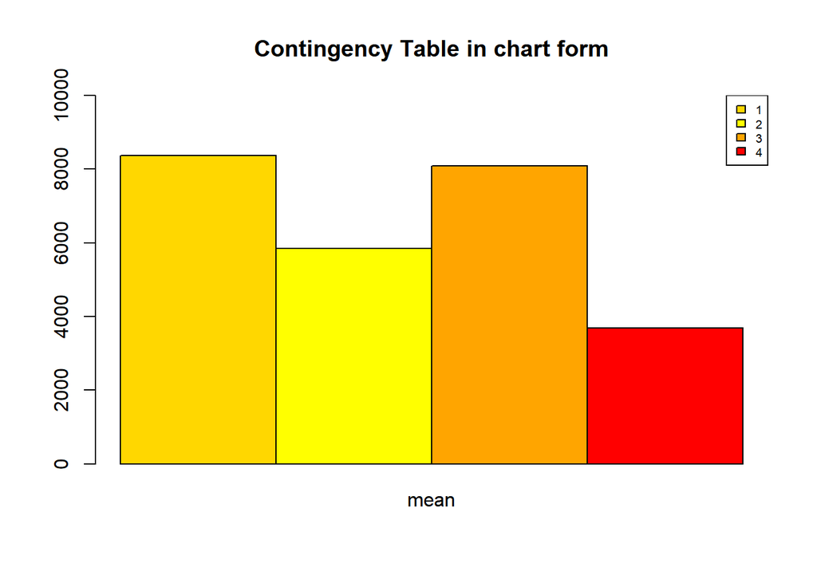

```r
##2a(iv)
sales.mat <- as.matrix(sales_by_firm[,3])
col.sales <- c("gold","yellow","orange","red")
barplot(sales.mat,
        beside = TRUE,
        col = col.sales,
        main = "Contingency Table in chart form",
        ylim = c(0,10000))
legend("topright",legend=sales_by_firm$firm, cex=0.6, fill=col.sales, )
```

```r
##2a(v)
correlation <- cor(CS_firm$sales, CS_firm$roe)
print(paste("Correlation value is:" ,correlation))
```

```
## [1] "Correlation value is: -0.0553857125450732"
```

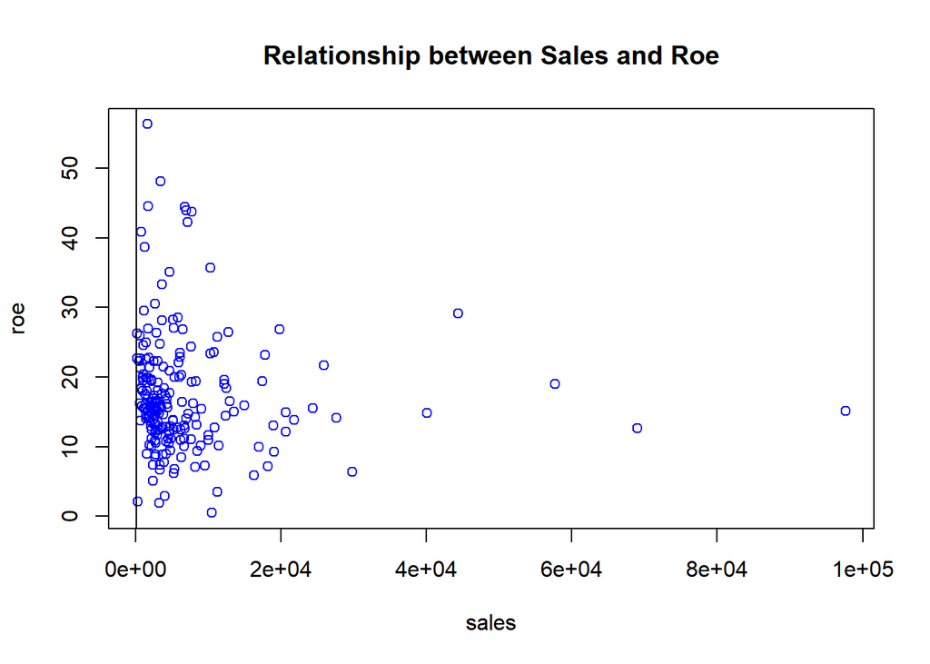

```r
plot(CS_firm$sales, CS_firm$roe, col='blue', main='Relationship between Sales and Roe', xlab = 'sales', ylab='roe')
abline(lm(CS_firm$sales~CS_firm$roe))
```

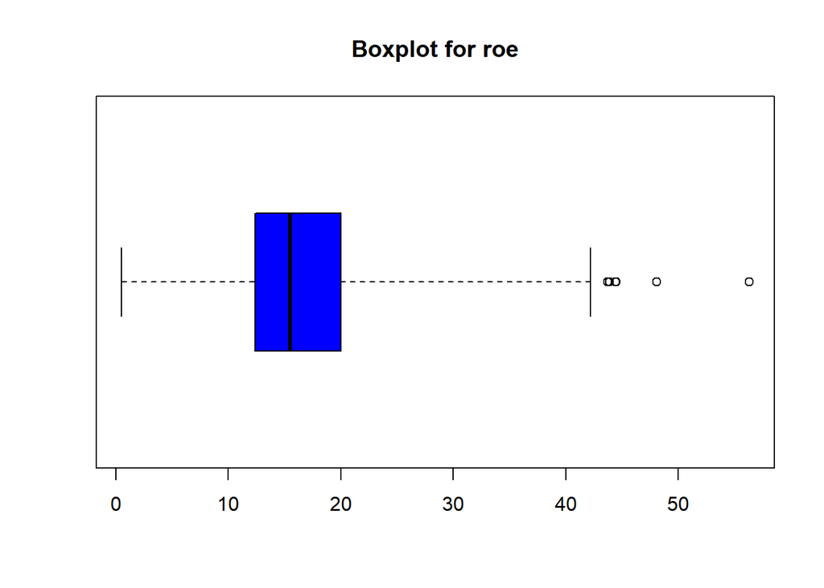

```r
##2a(vi)
boxplot(CS_firm$roe,
        range=3,
        horizontal = TRUE,
        col="blue",
        main = "Boxplot for roe")
```

```r
roe_out <- boxplot.stats(CS_firm$roe)$out
roe_out
```

```
##  [1] 56.3 38.7  0.5 33.3 35.7 44.4 43.7 44.5 35.1 43.9 42.2 48.1 40.8
```

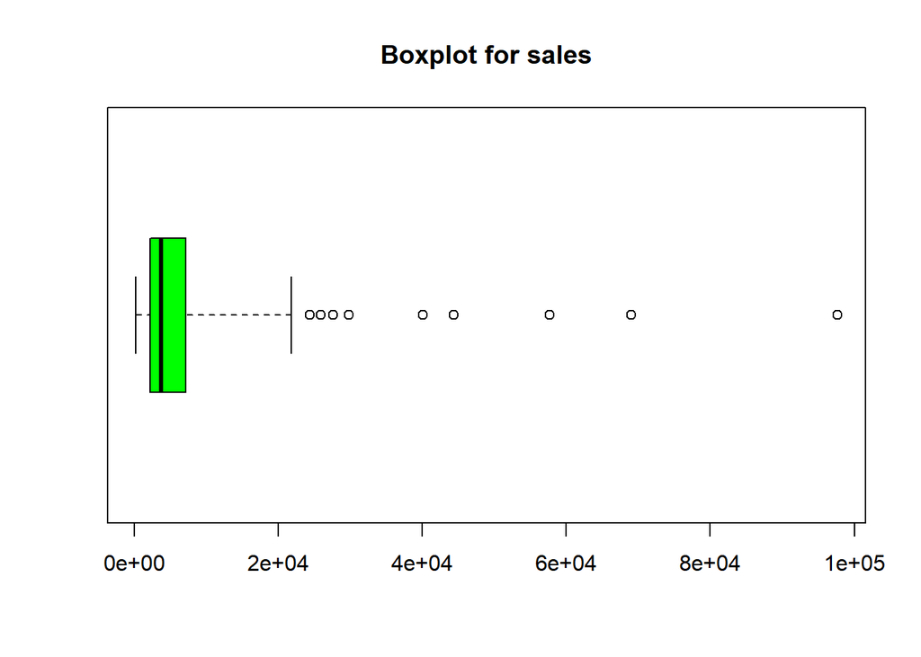

```r
boxplot(CS_firm$sales,
        range=3,
        horizontal=TRUE,
        col="green",
        main = "Boxplot for sales")
```

```r
sales_out <- boxplot.stats(CS_firm$sales)$out
sales_out
```

```
##  [1] 27595.0 16246.0 21783.2 19773.0 40047.0 57662.0 20604.0 20659.0 69018.0
## [10] 16951.0 19020.5 24332.0 14932.1 18164.0 29797.0 97649.9 17802.7 17453.8
## [19] 18908.0 25848.0 44323.0
```

2a(iii) Generally, we can observe high skewness and kurtosis coefficients of of sales across all firms. This suggests that the sales of all firms are positively skewed from the median sales and the data is peaked with little dispersion. On the other hand, the skewness of roe across all firms are milder, as seen from the less positive skewness coefficient. It is also notable that for firm 4, the skewness of roe has a negative value, implying that the data is left-skewed. In addition, the roe data is also rather flat compared to that of the sales data, with the exception of firm 1 which has a kurtosis coefficient of more than 3.

2a(v) Since the absolute correlation value obtained is far from 1, there is little linear relation between sales and roe. This can also be seen from the vast degree of deviation from the linear line plotted on the graph.

**END: YOUR ANSWER**

### Q2.(b) CEO Salary Analytics Dashboard

Next, you will build a dashboard to display the descriptive analytics for `salary`.

- 1. 1. Plot a histogram for `salary`. What can you deduce about the distribution of CEO salaries from this histogram? [1 mark]
- 2. Generate the descriptive statistics for `salary` by `firm` type in a contingency table. You are required to present only the following descriptive statistics in the table: n (or number of observations), mean, standard deviation, min, max, skewness coefficient, kurtosis. [2 marks]
- 3. Generate a chart that will facilitate the comparison of means of `salary` by `firm` type as well as standard deviations of `salary` by `firm` type. [2 marks]
- 4. Describe what you observe from the chart in 2b(iii). [1 mark]
- 22. You were asked to use the existing data to compute and display on the dashboard, the probability of the following events: 1) `salary` of CEOs being lower than $1 million, 2) `salary` of CEO from financial firm being more than $2million. [2 marks]

**BEGIN: YOUR ANSWER**

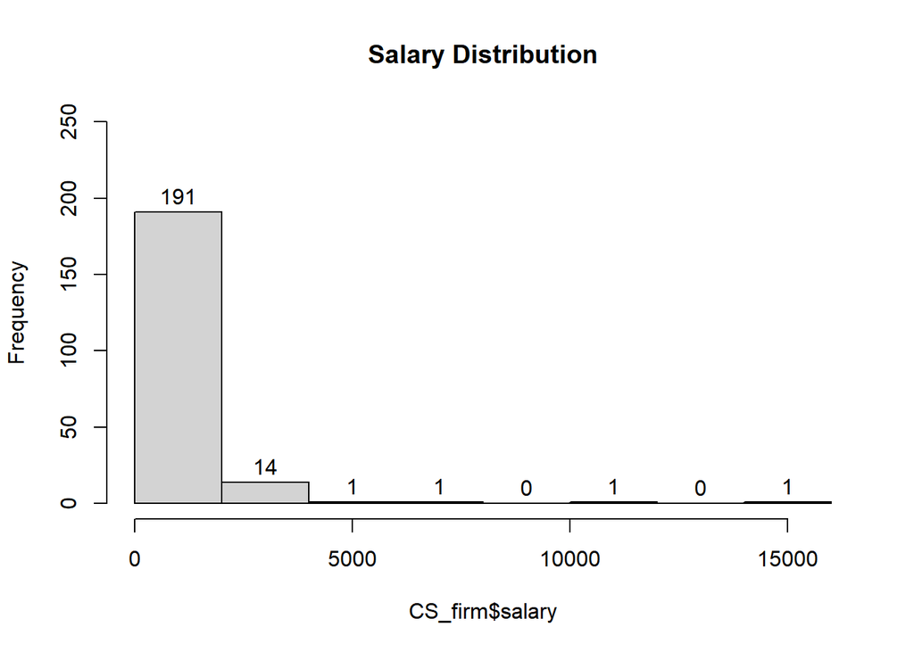

```r
##Enter your codes here
##2b(i)
hist(CS_firm$salary,
     main = "Salary Distribution",
     labels = TRUE,
     ylim = c(0,250))
```

```r
##2b(ii)
salary_by_firm <- CS_firm %>%
  select(salary, firm) %>%
  group_by(firm) %>%
  summarise(n = n(),
            mean = mean(salary),
            standard_deviation = sd(salary),
            median = median(salary),
            min = min(salary),
            max = max(salary),
            skewness_coefficient = skew(salary),
            kurtosis = kurtosi(salary))
kable(salary_by_firm, caption = "CEO salary distribution by Firm")
```

CEO salary distribution by Firm

| firm | n | mean | standard_deviation | median | min | max | skewness_coefficient | kurtosis |
| --- | --- | --- | --- | --- | --- | --- | --- | --- |
| 1 | 67 | 1139.3433 | 571.8732 | 1041.0 | 256 | 3844 | 2.139880 | 6.867815 |
| 2 | 46 | 1344.9130 | 1002.8131 | 1119.5 | 441 | 6640 | 3.612824 | 15.301660 |
| 3 | 60 | 1722.4167 | 2242.6870 | 1246.0 | 223 | 14822 | 4.572659 | 21.823548 |
| 4 | 36 | 727.9722 | 334.3349 | 646.0 | 333 | 1910 | 1.807115 | 3.307247 |

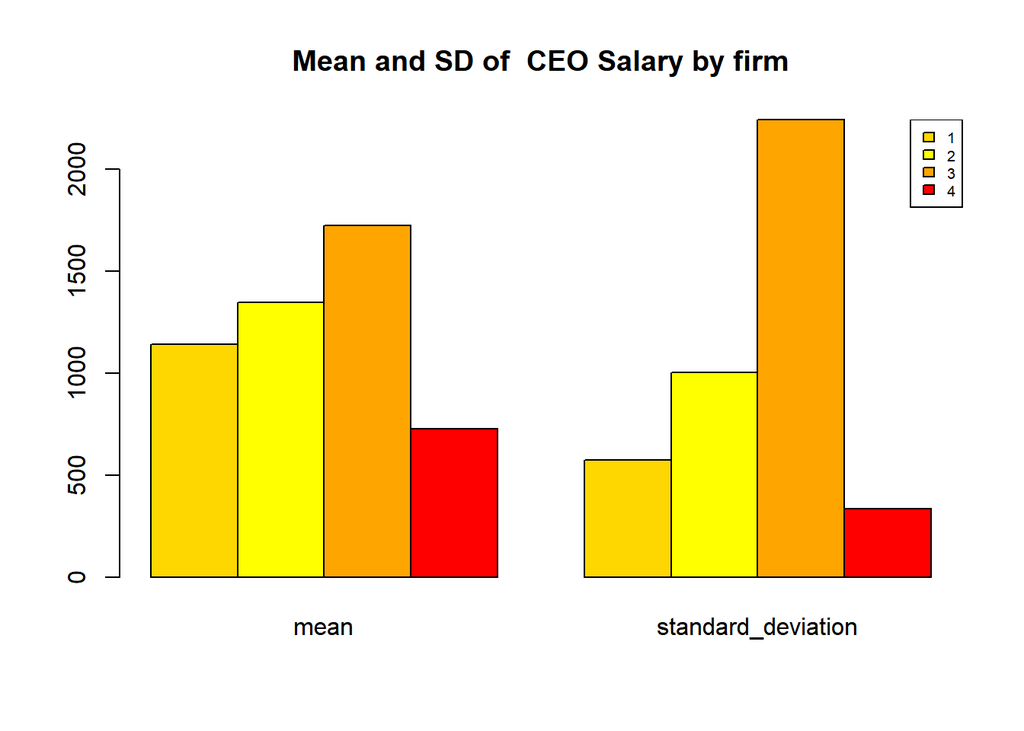

```r
##2b(iii)
salary_mean = as.matrix(salary_by_firm[,3:4])
barplot(salary_mean,
        beside = TRUE,
        col = col.sales,
        main = "Mean and SD of  CEO Salary by firm")
legend("topright", legend = salary_by_firm$firm, fill = col.sales, cex=0.6)
```

```r
##2b(v)
less_than_1mil <- CS_firm[CS_firm$salary < 1000,]
more_than_2mil <- CS_firm[CS_firm$salary > 2000,]

prob_less <- round(nrow(less_than_1mil)/nrow(CS_firm),3)
prob_more <- round(nrow(more_than_2mil)/nrow(CS_firm),3)
print(paste("Probability of CEO earning less than 1 million is", prob_less))
```

```
## [1] "Probability of CEO earning less than 1 million is 0.478"
```

```r
print(paste("Probability of CEO earning more than 2 million is", prob_more))
```

```
## [1] "Probability of CEO earning more than 2 million is 0.086"
```

2b(iv) On average, CEOs of firm 3 are paid the most while firm 4 CEO is paid the least. In addition, the salary received by the CEO of firm 3 has the highest standard deviation and that of firm 4 has the lowest standard deviation.

2b(v) Therefore, the probability of CEO earning less than 1 million is 0.478 while the probability of CEO earning more than 2 million is 0.086

**END: YOUR ANSWER**